# Exercise 1

```python
# Importing libs
import cv2
import os
import numpy as np
import datetime
import matplotlib.pyplot as plt
```

## 1. Describe the distribution of photoreceptors cells on retina and their impact on vision perception.

On retina there are two kind of photoreceptors cells, rods and cones. The retinas have around 75 M and 100M rods, also these rods are low illumination sensitive and have monochromatic perception. The second type has lower presence than rods, around 6M and 7M. They are responsible to percept colors and are concentrade on fovea.

## 2. Whats the difference of the cones S, M and L? Which are more activated when a yellow light is projected on retina?

The difference of three cones is the frequency, also the quantity of them in human eyes. Always, the number of S cones is lower than others. The other two, may variety. Based on RGB colors, the yellow has value equals: R:255, G:255, B:0. Thus, the most activated cones with yellow light are the medium and large, as picture bellow:

[figure not shown]

## 3. Write a program to:

#### a) Open an image and show on screen the 3 channels separately:

[figure not shown]

```python
nemo1 = cv2.imread('images/nemo1.jpg')
nemo1 = cv2.cvtColor(nemo1, cv2.COLOR_BGR2RGB)

nemo_h, nemo_w, _ = nemo1.shape

plt.imshow(nemo1)
plt.axis('off')
plt.figtext(0.5, 0, 'Original', horizontalalignment='center')
plt.show()
```

[figure not shown]

```python
nemo1_r = nemo1[:,:,0]
nemo1_g = nemo1[:,:,1]
nemo1_b = nemo1[:,:,2]
zeros = np.zeros((nemo_h, nemo_w), 'uint8')

nemo1_r_colorful = cv2.merge((nemo1_r, zeros, zeros))
nemo1_g_colorful = cv2.merge((zeros, nemo1_g, zeros))
nemo1_b_colorful = cv2.merge((zeros, zeros, nemo1_b))

# Defining figure size
plt.figure(figsize=(20,10))
ax1 = plt.subplot(231)
ax1.imshow(nemo1_r, cmap='gray')
ax2 = plt.subplot(232)
ax2.imshow(nemo1_g, cmap='gray')
ax3 = plt.subplot(233)
ax3.imshow(nemo1_b, cmap='gray')

ax4 = plt.subplot(234)
ax4.imshow(nemo1_r_colorful)
ax5 = plt.subplot(235)
ax5.imshow(nemo1_g_colorful)
ax6 = plt.subplot(236)
ax6.imshow(nemo1_b_colorful)

ax1.axis('off')
ax2.axis('off')
ax3.axis('off')
ax4.axis('off')
ax5.axis('off')
ax6.axis('off')

ax1.text(0.5,-0.1, "Red channel", ha="center", transform=ax1.transAxes)
ax2.text(0.5,-0.1, "Green channel", ha="center", transform=ax2.transAxes)
ax3.text(0.5,-0.1, "Blue channel", ha="center", transform=ax3.transAxes)
ax4.text(0.5,-0.1, "Colorful red channel", ha="center", transform=ax4.transAxes)
ax5.text(0.5,-0.1, "Colorful green channel", ha="center", transform=ax5.transAxes)
ax6.text(0.5,-0.1, "Colorful blue channel", ha="center", transform=ax6.transAxes)

plt.show()
```

#### b) Open an image and show on screen the horizontally inverted image:

[figure not shown]

```python
def flip(src):
    rows, cols, d = src.shape
    dst = np.zeros((rows, cols, d), dtype='uint8')
    for r in range(rows):
        for c in range(cols//2):
            dst[r,c] = src[r, (cols-1)-c]
            dst[r, (cols-1)-c] = src[r,c]

    return dst

nemo2 = cv2.imread('images/nemo2.jpg')
nemo2 = cv2.cvtColor(nemo2, cv2.COLOR_BGR2RGB)
nemo2_flipped = flip(nemo2)
nemo2_flipped_cv2 = cv2.flip(nemo2, 1)

plt.figure(figsize=(20,10))
ax1 = plt.subplot(131)
ax1.imshow(nemo2)
ax2 = plt.subplot(132)
ax2.imshow(nemo2_flipped)
ax3 = plt.subplot(133)
ax3.imshow(nemo2_flipped_cv2)

ax1.axis('off')
ax2.axis('off')
ax3.axis('off')

ax1.text(0.5,-0.1, "Original image", ha="center", transform=ax1.transAxes)
ax2.text(0.5,-0.1, "Flipped image", ha="center", transform=ax2.transAxes)
ax3.text(0.5,-0.1, "Flipped image by OpenCV", ha="center", transform=ax3.transAxes)

plt.show()
```

#### c) Open two images (a,b) of same size and show on screen a new image (c) with the blending of both images, using linear combination between them:

[figure not shown]

```
Seconds to process:  3.972292
```

```python
def blending(img1, img2, a=.5, b=.5):
    rows, cols, d = img1.shape
    dst = np.zeros((rows, cols, d), dtype='uint8')

    for r in range(rows):
        for c in range(cols):
            dst[r,c] = a*img1[r,c] + b*img2[r,c]

    return dst

start = datetime.datetime.now()
blended_nemo = blending(nemo1, nemo2)
end = datetime.datetime.now()

plt.figure(figsize=(20,10))
ax1 = plt.subplot(131)
ax1.imshow(nemo1)
ax2 = plt.subplot(132)
ax2.imshow(nemo2)
ax3 = plt.subplot(133)
ax3.imshow(blended_nemo)

ax1.axis('off')
ax2.axis('off')
ax3.axis('off')

ax1.text(0.5,-0.1, "Nemo 1", ha="center", transform=ax1.transAxes)
ax2.text(0.5,-0.1, "Nemo 2", ha="center", transform=ax2.transAxes)
ax3.text(0.5,-0.1, "Blended Nemo", ha="center", transform=ax3.transAxes)
plt.show()

delta = end-start
print('Seconds to process: ', delta.total_seconds())
```

[figure not shown]

```
Seconds to process:  0.034444
```

```python
def blending_fast(img1, img2, a=.5, b=.5):
    dst = a*img1 + b*img2
    dst = dst.astype(int)
    return dst

start = datetime.datetime.now()
blended_nemo = blending_fast(nemo1, nemo2)
end = datetime.datetime.now()

plt.figure(figsize=(20,10))
ax1 = plt.subplot(131)
ax1.imshow(nemo1)
ax2 = plt.subplot(132)
ax2.imshow(nemo2)
ax3 = plt.subplot(133)
ax3.imshow(blended_nemo)

ax1.axis('off')
ax2.axis('off')
ax3.axis('off')

ax1.text(0.5,-0.1, "Nemo 1", ha="center", transform=ax1.transAxes)
ax2.text(0.5,-0.1, "Nemo 2", ha="center", transform=ax2.transAxes)
ax3.text(0.5,-0.1, "Blended Nemo", ha="center", transform=ax3.transAxes)
plt.show()

delta = end-start
print('Seconds to process: ', delta.total_seconds())
```

#### d) Create a new vertical gradient image:

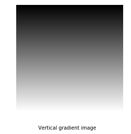

```python
def gradient_vertical(min_color, max_color, width, height):
    image = min_color + np.zeros((height,width), dtype='float')

    ratio = (max_color - min_color) / height

    for h in range(height):
        if h > 0:
            image[h,:] = image[h-1,:] + ratio
    return image

gv = gradient_vertical(0, 255, 300, 300)
plt.imshow(gv, cmap='gray')
plt.axis('off')
plt.figtext(0.5, 0, 'Vertical gradient image', horizontalalignment='center')
plt.show()
```

## 4. Consider the NetPBM format:

### a) What is the difference of magic numbers P1, P2, P3, P4, P5 and P6?

The magic numbers are important to identify the type of files. P1 and P4 are for *Portable BitMap* format, ASCII and Binary, respectively. P2 and P5 are for *Portable GrayMap* format, ASCII and Binary, respectively. The last two, P3 and P6 are for *Portable PixMap* format, ASCII and Binary, respectively.

### b) Convert a JPG image for PBM (ASCII), using convert:

[figure not shown]

```python
!convert -compress none "images/nemo1.jpg" "images/nemo1.pbm"
pbm = cv2.imread('images/nemo1.pbm')
plt.imshow(pbm)
plt.axis('off')
plt.figtext(0.5, 0, 'PBM file', horizontalalignment='center')
plt.show()
```

```python
!convert -compress none "images/nemo1.jpg" "images/nemo1.pbm"
print('pbm (ASCII) file size: ', os.path.getsize("images/nemo1.pbm") / 1000, 'kb')

!convert -compress Undefined "images/nemo1.jpg" "images/nemo1.pbm"
!convert -compress Undefined "images/nemo1.jpg" "images/nemo1.ppm"
print('pbm (binary) file size: ', os.path.getsize("images/nemo1.pbm") / 1000, 'kb')
print('ppm (binary) file size: ', os.path.getsize("images/nemo1.ppm") / 1000, 'kb')
```

```
pbm (ASCII) file size:  972.382 kb
pbm (binary) file size:  60.074 kb
ppm (binary) file size:  1440.078 kb
```

### d) Why does the binary format take up less space than ASCII format?

Because the binary format needs less bits to save the same information. With ASCII format it is needed store information about space, type of image, and each pixel.

### e) Why does the binary PPM take up more space than binary PBM?

The PPM format stores information of three channels; Each one may have values between 0 and 255. On the other hand, the PBM only store one channel and 2 possible values: 0 and 1.

## 5. Which are the vector formats and which are bitmaps?

- Vector:
  - SVG.
  - EPS.
- Bitmaps:
  - BMP
  - JPG
  - PNG

## 6. Using the nine available pictures, create a program to generate a new one with attenuated noise.

[figure not shown]

```
Seconds to process:  37.964078
```

```python
def attenuate_noise(imgs):
    length = len(imgs)
    rows, cols = imgs[0].shape
    result = np.zeros((rows, cols), dtype='uint8')

    for r in range(rows):
        for c in range(cols):
            result[r,c] = np.mean([ imgs[i][r,c] for i in range(length)])

    return result

figures = [cv2.imread('images/a' + str(i) + '.jpg', 0) for i in range(1, 10)]
plt.figure(figsize=(15,5))
for i in range(9):
    ax = plt.subplot(2,5,i+1)
    ax.imshow(figures[i], cmap='gray')
    ax.axis('off')
    ax.text(0.5,-0.1, "Image " + str(i+1), ha="center", transform=ax.transAxes)

start = datetime.datetime.now()
attenuated = attenuate_noise(figures)
end = datetime.datetime.now()

ax = plt.subplot(2,5,10)
ax.imshow(attenuated, cmap='gray')
ax.axis('off')
ax.text(0.5,-0.1, "Attenuated image", ha="center", transform=ax.transAxes)
plt.show()

delta = end-start
print('Seconds to process: ', delta.total_seconds())
```

[figure not shown]

```
Seconds to process:  0.060082
```

```python
def attenuate_noise_fast(imgs):
    length = len(imgs)
    rows, cols = imgs[0].shape
    result = np.zeros((rows, cols), dtype=int)

    for img in imgs:
        result = result + img

    result = result // length
    return result

plt.figure(figsize=(15,5))
for i in range(9):
    ax = plt.subplot(2,5,i+1)
    ax.imshow(figures[i], cmap='gray')
    ax.axis('off')
    ax.text(0.5,-0.1, "Image " + str(i+1), ha="center", transform=ax.transAxes)

start = datetime.datetime.now()
attenuated = attenuate_noise_fast(figures)
end = datetime.datetime.now()

ax = plt.subplot(2,5,10)
ax.imshow(attenuated, cmap='gray')
ax.axis('off')
ax.text(0.5,-0.1, "Attenuated image", ha="center", transform=ax.transAxes)
plt.show()

delta = end-start
print('Seconds to process: ', delta.total_seconds())
```